# Chapter12 様々なグラフを作る

### 12-1

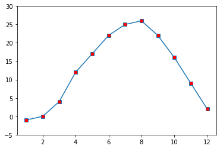

```python
import matplotlib.pyplot as plt
import numpy as np
%matplotlib inline

# X軸データ(1から12までの整数)
x = list(range(1,13))

# Y軸データ(問題文の値)
y = [-1, 0, 4, 12, 17, 22, 25, 26, 22, 16, 9, 2]

# Y軸の表示範囲を-5～30とする
plt.ylim(-5,30)

# データx,yをグラフにプロット
# 線のスタイルを点線、線の色を緑に設定
# マーカーを四角、マーカーの色を赤に設定
plt.plot(x, y, marker="s", markerfacecolor="r")

# グラフ表示
plt.show()
```

### 12-2

以下の条件で棒グラフを作成するプログラムを完成させなさい。  
（参考：12.2.1 棒グラフを作成する、12.2.2 横軸にラベルを設定する）

- 横軸のデータは1から5までの整数とする（1, 2,...,5）
- 縦軸のデータは [ 26, 14, 40, 34, 21 ] とする
- 横軸のラベルは ["Sapporo", "Chitose", "Ishikari", "Otaru", "Yoichi" ] とする

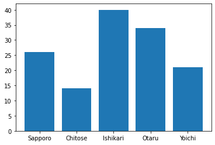

```python
import numpy as np
import matplotlib.pyplot as plt
%matplotlib inline

# 横軸データ(1から5までの整数)
x = list(range(1,6))

# 縦軸データ(問題文の値)
y = [26, 14, 40, 34, 21]

# 横軸のラベル(問題文の値)
labels =["Sapporo", "Chitose", "Ishikari", "Otaru", "Yoichi"]

# 棒グラフを作成し、横軸にラベルを設定する
plt.bar(x, y, tick_label=labels)

plt.show()
```

### 12-3

以下の条件で積み上げ棒グラフを作成するプログラムを完成させなさい。  
（参考：12.2.3 積み上げ棒グラフを作成する）

- 横軸のデータは1から6までの整数とする（1, 2,...,6）
- 縦軸の下段のデータ **y1** は [ 749, 1017, 1149, 1028, 368, 342 ] とする
- 縦軸の上段のデータ **y2** は [ 773, 912, 843, 419, 668, 601 ] とする
- 横軸のラベルは ["Tokyo", "Osaka", "Nagoya", "Yokohama", "Sapporo", "Fukuoka" ] とする
- 凡例を表示する

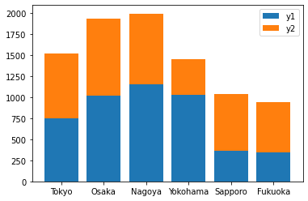

```python
import numpy as np
import matplotlib.pyplot as plt
%matplotlib inline

# 横軸データ(1から6までの整数)
x = list(range(1,7))

# 縦軸下段のデータ(問題文の値)
y1 = [749, 1017, 1149, 1028, 368, 342]

# 縦軸上段のデータ(問題文の値)
y2 = [773, 912, 843, 419, 668, 601]

# 横軸のラベルデータ（問題文の値）
labels = ["Tokyo", "Osaka", "Nagoya", "Yokohama", "Sapporo", "Fukuoka" ]

# 積み上げ棒グラフを作成（下段のデータで作成する）
plt.bar(x, y1, tick_label=labels)

# y1の値の上にy2の値を積み上げる
plt.bar(x, y2, bottom=y1)

# 凡例を作成
plt.legend(("y1", "y2"))

plt.show()
```

### 12-4

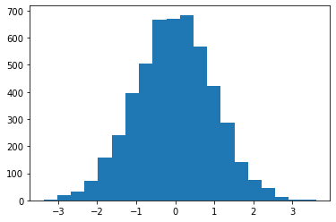

```python
import numpy as np
import matplotlib.pyplot as plt
%matplotlib inline

# 乱数のシードを10に設定
np.random.seed(10)

# 正規分布に従う乱数を5000個生成
data = np.random.randn(5000)

# ビン数20の正規化されたヒストグラムを作成する
plt.hist(data, bins=20)

plt.show()
```

### 12-5

12-4で作成したヒストグラムと同じデータで、累積ヒストグラムを作成するプログラムを完成させなさい。  
（参考：12.3.4 累積ヒストグラムを作成する）

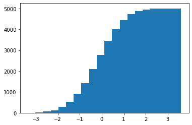

```python
import numpy as np
import matplotlib.pyplot as plt
%matplotlib inline

# 乱数のシードを10に設定
np.random.seed(10)

# 正規分布に従う乱数を5000個生成
data = np.random.randn(5000)

# ビン数20の正規化されたヒストグラムを作成する
plt.hist(data, bins=20, cumulative=True)

plt.show()
```

### 12-6

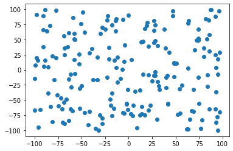

```python
import numpy as np
import matplotlib.pyplot as plt
%matplotlib inline

np.random.seed(0)

# x軸、y軸データを作成
# (-100～99までの整数から重複を許してランダムに選択した200個のデータ)
x = np.random.choice(np.arange(-100, 100), 200)
y = np.random.choice(np.arange(-100, 100), 200)

# 散布図を作成
# マーカーとして星、色を赤に設定
plt.scatter(x, y)

plt.show()
```

### 12-7

以下の条件で散布図を作成するプログラムを完成させなさい。  
（参考：12.4.3 値に応じてマーカーの大きさを設定する）

- x軸のデータ、y軸のデータとも、-100～99までの整数から重複を許してランダムに選択した200個のデータとする
- マーカーの大きさを表現するデータ **z** を、0～99までの整数から重複を許してランダムに選択した200個のデータとする
- マーカーを四角、色を黒に設定する

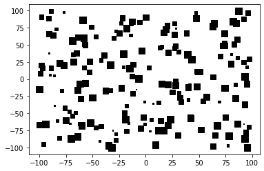

```python
import numpy as np
import matplotlib.pyplot as plt
%matplotlib inline

np.random.seed(0)

# x軸、y軸データを作成
# (-100～99までの整数から重複を許してランダムに選択した200個のデータ)
x = np.random.choice(np.arange(-100, 100), 200)
y = np.random.choice(np.arange(-100, 100), 200)

# マーカーの大きさを表現するデータを作成
z = np.random.choice(np.arange(100), 200)

# 散布図を作成
# zのデータを用いてマーカーの大きさを指定
# マーカーとして四角、色を黒に設定
plt.scatter(x, y, s=z, marker="s", color="k")

plt.show()
```

### 12-8

以下の条件で散布図を作成するプログラムを完成させなさい。  
（参考：12.4.4 値に応じてマーカーの濃さを設定する、12.4.5 カラーバーを表示する）

- 図の大きさを縦横ともに6インチとする
- x軸、y軸とも表示範囲を-4～4とする
- x軸のデータ、y軸のデータとも、正規分布に従う乱数2000個とする
- マーカーの濃さを表現するデータ **z** も、正規分布に従う乱数2000個とする
- マーカーの色は緑系統とする
- カラーバーを表示する

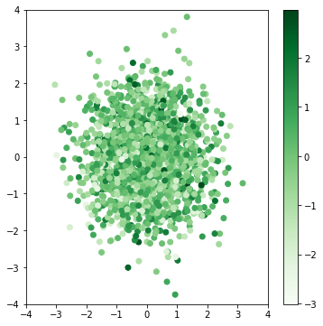

```python
import numpy as np
import matplotlib.pyplot as plt
%matplotlib inline

np.random.seed(0)

# x軸、y軸、z軸データを作成
x = np.random.normal(size=2000)
y = np.random.normal(size=2000)
z = np.random.normal(size=2000)

# 図の大きさを縦横ともに6インチとする
plt.figure(figsize=(6, 6))

# X軸の範囲を-4～4に設定
plt.xlim(-4,4)

# Y軸の範囲を-4～4に設定
plt.ylim(-4,4)

# zの値に応じて、マーカーの濃さが緑系統で変わるようにプロット
plt.scatter(x, y, c=z, cmap="Greens")

# カラーバーを表示
plt.colorbar()

plt.show()
```

### 12-9

以下の条件で円グラフを作成するプログラムを完成させなさい。  
（参考：12.5.1 円グラフを作成する～12.5.3 特定の要素を目立たせる）

- データは [ 24, 23, 19, 8, 7, 4, 15 ] とする
- データに対応するラベルは [ "Korea", "China", "Taiwan", "Thailand", "HongKong", "Malaysia", "Other" ] とする
- データの目立たせ度合いについて、"Taiwan"のデータを0.2、その他は0とする
- 円グラフが真円となるようaxisの設定をする

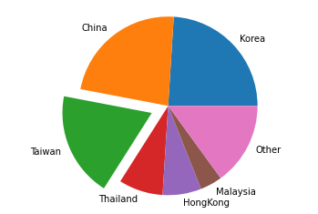

```python
import numpy as np
import matplotlib.pyplot as plt
%matplotlib inline

# 円グラフデータの設定
data = [24, 23, 19, 8, 7, 4, 15]

# データに対応するラベルの設定
labels = ["Korea", "China", "Taiwan", "Thailand", "HongKong", "Malaysia", "Other"]

# データの目立たせ度合いの設定
explode = [0, 0, 0.2, 0, 0, 0, 0]

# 円グラフの作成
plt.pie(data, labels=labels, explode=explode)

# 真円になるようaxisの設定
plt.axis("equal")

plt.show()
```

### 12-10

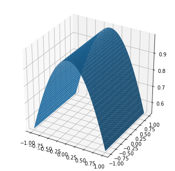

```python
import numpy as np
import matplotlib.pyplot as plt
# 3D描画を行うために必要なライブラリのimport文を追加
from mpl_toolkits.mplot3d import Axes3D
# カラーマップを表示するためのライブラリのimport文を追加
from matplotlib import cm

%matplotlib inline

# X軸データ
x = np.linspace(-1, 1, 50)
# Y軸データ
y = np.linspace(-1, 1, 50)

# X軸・Y軸データを組み合わせた格子状のデータを作成
X, Y = np.meshgrid(x,y)

# Z軸データ
Z = np.cos(X)

# 大きさが縦横とも6インチのFigureオブジェクトを作成
fig = plt.figure(figsize=(6, 6))

# 3D描画できるサブプロットaxを作成
ax = fig.add_subplot(1, 1, 1, projection="3d")

# 曲面をプロット
# Zの値についてカラーマップを適用
ax.plot_surface(X, Y, Z)

plt.show()
```

### 12-11

以下の条件で3Dヒストグラムを作成するプログラムを完成させなさい。  
（参考：12.6.3 3Dヒストグラムを作成する）

- 3D描画に必要なライブラリのimport文を追加する
- 大きさが縦横とも5インチのFigureオブジェクトを作成する
- 各軸のデータは以下の通りとする
  - X軸、Y軸：[ 9, 8, 7, 6, 5, 4, 3, 2, 1, 0 ]
  - Z軸：全て0
- 各軸のデータの増加量は以下の通りとする
  - X軸、Y軸：全て1
  - Z軸：[ 0, 1, 2, 3, 4, 5, 6, 7, 8, 9 ]

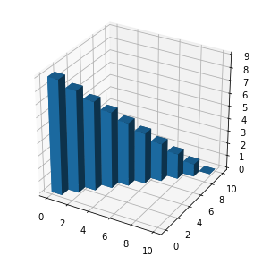

```python
import matplotlib.pyplot as plt
import numpy as np
# 3D描画を行うために必要なライブラリのimport文を追加
from mpl_toolkits.mplot3d import Axes3D

%matplotlib inline

# 大きさが縦横とも5インチのFigureオブジェクトを作成
fig = plt.figure(figsize=(5, 5))

# 3D描画できるサブプロットaxを作成
ax = fig.add_subplot(1, 1, 1, projection="3d")

# x軸, y軸, z軸のデータ設定
xpos = list(range(9,-1,-1))
ypos = list(range(9,-1,-1))
zpos = np.zeros(10)

# x軸, y軸, z軸のデータの増加量設定
dx = np.ones(10)
dy = np.ones(10)
dz = list(range(10))

# 3Dヒストグラムの作成
ax.bar3d(xpos, ypos, zpos, dx, dy, dz)

plt.show()
```

### 12-12

以下の条件で3D散布図を作成するプログラムを完成させなさい。  
（参考：12.6.4 3D散布図を作成する）

- 3D描画に必要なライブラリのimport文を追加する
- 大きさが縦横とも6インチのFigureオブジェクトを作成する
- 各軸のデータは以下の通りとする
  - X軸、Y軸、Z軸：1～99までの整数から重複を許してランダムに選択した500個のデータ

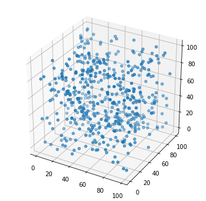

```python
import numpy as np
import matplotlib.pyplot as plt
# 3D描画を行うために必要なライブラリのimport文を追加
from mpl_toolkits.mplot3d import Axes3D

%matplotlib inline
np.random.seed(0)

# 大きさが縦横とも6インチのFigureオブジェクトを作成
fig = plt.figure(figsize=(6, 6))

# 3D描画できるサブプロットaxを作成
ax = fig.add_subplot(1, 1, 1, projection="3d")

# x軸, y軸, z軸のデータ設定
# 1～99までの整数から重複を許してランダムに選択した500個のデータ
X = np.random.choice(np.arange(100), 500)
Y = np.random.choice(np.arange(100), 500)
Z = np.random.choice(np.arange(100), 500)

# 3D散布図を作成
ax.scatter3D(X, Y, Z)

plt.show()
```